# DATASCI 385 - Experimental Methods

Lecture 05 - Sampling Distributions, Statistical Inference, and Hypothesis Testing

Danilo Freire

danilo.freire@emory.edu

Department of Data and Decision Sciences  
Emory University

# Hello, everyone! 👋 How are you doing today? 😁

# Brief recap 📚

## Last time, we saw that…

- Selection bias arises when treatment groups differ initially
- Balance tests assess pre-treatment group comparability
  - Are they useful? Sometimes. Do they solve the problem? No. 😂
- Causal diagrams (DAGs) illustrate variable relationships and biases
  - Useful for identifying confounders and mediators
- Loss to follow-up can introduce bias in treatment effects
- Survivorship bias focuses on successful outcomes, ignoring failures
- Post-treatment bias occurs when controlling for variables affected by treatment
- Standard deviation quantifies the spread of data
- Standard error measures the precision of sample means (or other test statistics)
- Regression analysis is the most convenient way to estimate treatment effects
  - They can handle multiple covariates and interactions
- [DeclareDesign](https://declaredesign.org/) is a package for designing and analysing experiments
  - It helps you through the entire process! 😎

## Today, we will discuss…

- Regression analysis in `R` (from last week)
- Sampling distributions of experimental estimates
- The importance of randomisation inference
  - [`ri2` package](https://alexandercoppock.com/ri2/)
- Hypothesis testing
  - Sharp null hypothesis
  - Null hypothesis of no average treatment effect
  - Confidence intervals
- But first… interesting experiment of the day! 🎉
- And a few ideas about your pre-analysis plans and final project 😊

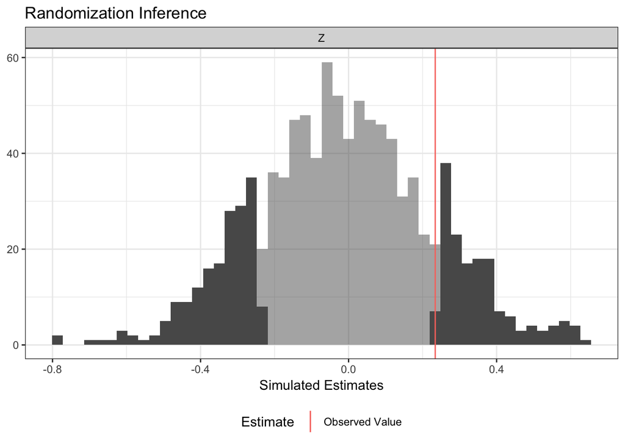

Source: [Alex Coppock](https://alexandercoppock.com/ri2/)

## Interesting experiment of the day! 🎉

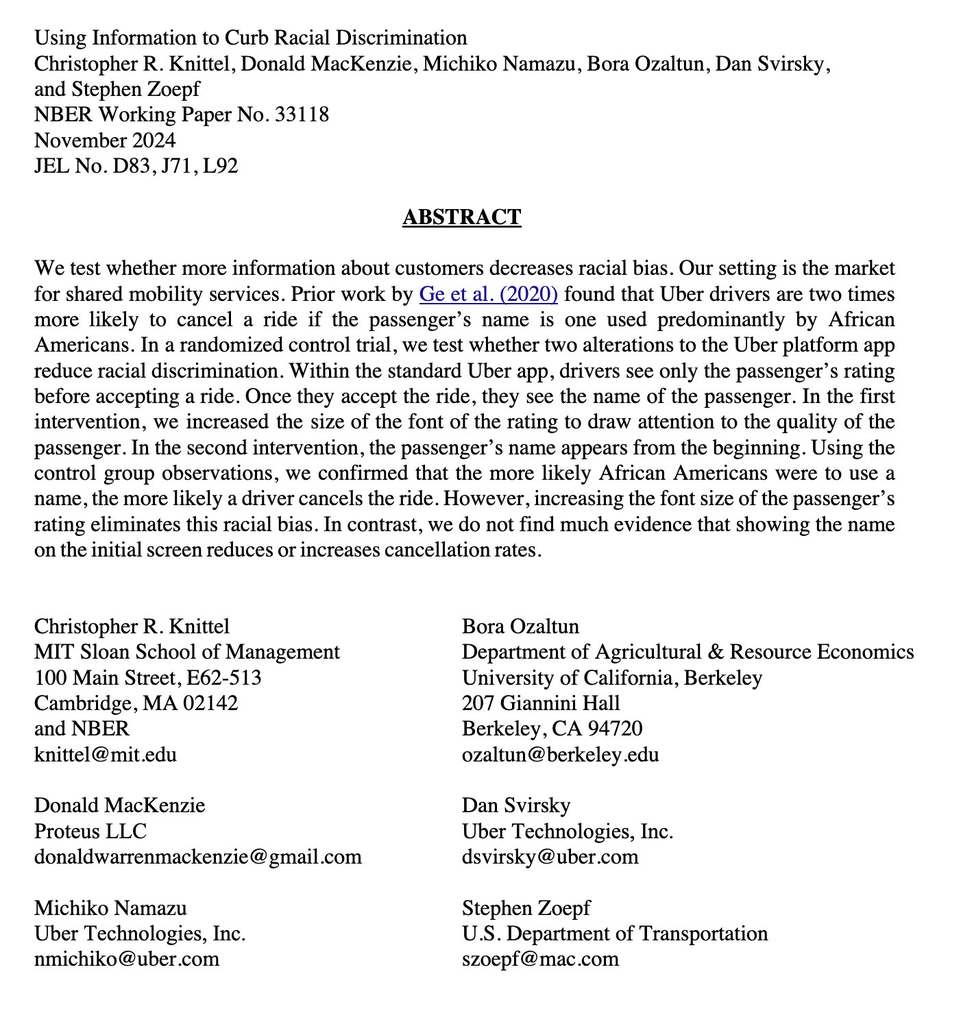

Source: [Knittel et al. (2024)](https://www.nber.org/papers/w33118)

## Pre-analysis plan and final project 😊

- Now we have the final list of students enrolled in the course!
- So we can start thinking about your project 🤓
- It will be a group project, with 4-5 students per group
- You will have to submit a pre-analysis plan, I will create a dataset for you to work on, and you will have to write a report
- And I have a few questions for you (don’t worry, they’re easy! 😂)

# Regression analysis in R (recap) 📊

## Simulating data in `R`

- Imagine that we want to estimate the effect of a job training programme on the number of interviews that unemployed individuals get, similar to the example we discussed earlier
- The treatment variable is `treat`, which takes the value 1 if the individual received the training and 0 otherwise
- We will assign 1000 individuals to the treatment and control groups, with an equal probability of being assigned to each group (simple random assignment)
- The outcome variable is `interviews`, which is the number of interviews the individual got after the training
- The treatment effect is 5, that is, individuals who received the training got 5 more interviews than those who did not

```r
# Load the required packages
library(fabricatr)
library(estimatr)
library(randomizr)

# Set the seed for reproducibility
set.seed(385)

# Simulate the data
data <- fabricate( # fabricatr
  N = 1000, # base
  treat = simple_ra(N, prob = 0.5), # randomizr
  interviews = round(rnorm(N, mean = 10, sd = 2) + 5 * treat, digits = 0) # base
)

# Check the first few rows of the data
head(data)
```

```
    ID treat interviews
1 0001     1         13
2 0002     0          8
3 0003     1         15
4 0004     1         17
5 0005     0         12
6 0006     1         15
```

## Randomising treatment assignment

- We used `simple_ra()` for simple random assignment, which is a simple coin flip. The arguments are:
  - `N`: the number of individuals in the sample (required)
  - `prob`: the probability of being assigned to the treatment group (optional)
  - `prob_each`: the probability of being assigned to each treatment group (optional)
- We could have used the `complete_ra()` function from the `randomizr` package to randomise the treatment assignment
- The function has a few arguments:
  - `N`: the number of individuals in the sample (required)
  - `m`: the number of individuals assigned to the treatment group (optional)
  - `m_each`: the number of individuals assigned to each treatment group (optional)
- We could also use `block_ra()` for block random assignment, which is when we divide the sample into blocks and then randomise within each block
- `cluster_ra()` is used for cluster random assignment, which is when we randomise at the cluster level (e.g. schools, hospitals)
- Finally, `block_and_cluster_ra()` is used for block and cluster random assignment, which is a combination of the two
- We will discuss these functions in further detail in the next lectures 😉

## Estimating the treatment effect

- Now that we have the data, we can estimate the treatment effect using the `lm_robust()` function from the `estimatr` package
- The function is similar to the `lm()` function, but it uses robust standard errors, which are more appropriate for experiments
- Why? Because [robust standard errors correct for heteroskedasticity and clustering](https://declaredesign.org/r/estimatr/articles/mathematical-notes.html#lm_robust-notes)
- This is a free lunch: if your data is not heteroskedastic or clustered, the robust standard errors will be the same as the regular standard errors
- The function takes a formula as an argument, which is the outcome variable regressed on the treatment variable

```r
model <- lm_robust(interviews ~ treat, data = data)
summary(model)
```

```
Call:
lm_robust(formula = interviews ~ treat, data = data)

Standard error type:  HC2

Coefficients:
            Estimate Std. Error t value   Pr(>|t|) CI Lower CI Upper  DF
(Intercept)   10.008    0.08986  111.37  0.000e+00    9.832   10.184 998
treat          4.958    0.12922   38.37 1.353e-198    4.704    5.211 998

Multiple R-squared:  0.5961 ,   Adjusted R-squared:  0.5957
F-statistic:  1472 on 1 and 998 DF,  p-value: < 2.2e-16
```

## Adding covariates

- We can add covariates to experimental models to increase precision
- The same way we do in any regression:
  - $Y_i = \alpha + \beta \text{T}_i + \gamma \text{X}_i + \epsilon_i$
- [Freedman (2008)](https://doi.org/10.1214/07-AOAS143) demonstrated that pre-treatment covariate adjustment may bias estimates of average treatment effects, mainly in small samples
- [Lin (2013)](https://doi.org/10.1214/12-AOAS583) proposed that if covariate correlations differ between treatment and control groups, centring and interacting covariates with the treatment variable will balance the groups
- This adjusts for covariates separately in each group, which is equivalent to including treatment-by-covariate interactions
  - $Y_i = \alpha + \beta \text{T}_i + \gamma \text{W}_i + \delta \text{T}_i \times \text{W}_i + \epsilon_i$
  - Where $W_i = \text{X}_i - \bar{\text{X}}$ and $\bar{\text{X}}$ is the mean of $\text{X}_i$
  - For ease of interpretation, we can centre the covariates to have a mean of zero
- Anyway, worry not! 😅 Our friends at [DeclareDesign](https://declaredesign.org/r/estimatr/articles/getting-started.html#lm_lin) have done all the work for us and created a function called `lm_lin()` that does everything automatically!

## Estimating the second model

```r
set.seed(385)

data2 <- fabricate(
  N = 1000,
  treat = complete_ra(N, m = 500),
  age = round(rnorm(N, mean = 30, sd = 5)),
  education = round(rnorm(N, mean = 12, sd = 2)),
  interviews = round(rnorm(N, mean = 10, sd = 2) + 5 * treat)
)

model2 <- lm_lin(interviews ~ treat,
                covariates = ~ age + education,
                data = data2)
summary(model2)
```

```
Call:
lm_lin(formula = interviews ~ treat, covariates = ~age + education,
    data = data2)

Standard error type:  HC2

Coefficients:
                  Estimate Std. Error  t value   Pr(>|t|)  CI Lower CI Upper
(Intercept)        9.88659    0.09213 107.3127  0.000e+00  9.705804 10.06738
treat              5.13084    0.12546  40.8956 3.281e-215  4.884642  5.37704
age_c              0.02845    0.01771   1.6062  1.085e-01 -0.006307  0.06320
education_c       -0.04550    0.04721  -0.9636  3.355e-01 -0.138150  0.04716
treat:age_c       -0.03324    0.02546  -1.3054  1.921e-01 -0.083206  0.01673
treat:education_c  0.04324    0.06140   0.7043  4.814e-01 -0.077248  0.16373
                   DF
(Intercept)       994
treat             994
age_c             994
education_c       994
treat:age_c       994
treat:education_c 994

Multiple R-squared:  0.6272 ,   Adjusted R-squared:  0.6254
F-statistic: 344.4 on 5 and 994 DF,  p-value: < 2.2e-16
```

- The `lm_lin()` function is similar to the `lm_robust()` function, but it includes the `covariates` argument
- As you can see, the results are pretty similar to the previous model
- The treatment effect is slightly higher, and the standard error is slightly smaller
- The `_c` part of the variable names indicates that the variables are centred

## Sub-group analysis

- We can also estimate the treatment effect for sub-groups of the population
- This is useful when we suspect that the treatment effect may vary across known dimensions
- For instance, we can estimate the treatment effect for people with high and low levels of education
- We can do this by including an interaction term between the treatment variable and the covariate of interest
- Interpretation: The treatment effect for the high-education subgroup (`high_edu = 1`) is 0.097 larger than for the low-education subgroup
- Total treatment effect for `high_edu = 1`: 5.101 + 0.097 = 5.198

```r
# Create a binary subgroup (e.g., "high" vs. "low" education)
data2$high_edu <- ifelse(data2$education > median(data2$education), 1, 0)

# Fit an interaction model with covariates
model_interaction <- lm_robust(
  interviews ~ treat * high_edu + age + education,
  data = data2)

# Summarise results
summary(model_interaction)
```

```
Call:
lm_robust(formula = interviews ~ treat * high_edu + age + education,
    data = data2)

Standard error type:  HC2

Coefficients:
               Estimate Std. Error t value   Pr(>|t|) CI Lower CI Upper  DF
(Intercept)     9.39778    0.69048 13.6104  8.255e-39  8.04281 10.75275 994
treat           5.10068    0.16905 30.1726 1.682e-142  4.76894  5.43241 994
high_edu       -0.26179    0.24257 -1.0792  2.808e-01 -0.73780  0.21422 994
age             0.01141    0.01276  0.8938  3.716e-01 -0.01363  0.03644 994
education       0.02033    0.05026  0.4046  6.859e-01 -0.07829  0.11895 994
treat:high_edu  0.09721    0.25093  0.3874  6.985e-01 -0.39521  0.58962 994

Multiple R-squared:  0.6269 ,   Adjusted R-squared:  0.625
F-statistic: 341.1 on 5 and 994 DF,  p-value: < 2.2e-16
```

# Hypothesis Testing 👩🏻‍🔬

## What is a hypothesis test? 🤔

- A hypothesis test is an evaluation of a particular hypothesis about the population distribution
- Statistical thought experiments:
  - Assume we know (part of) the true DGP
  - Use tools of probability to see what types of data we should see under this assumption
  - Compare our observed data to this thought experiment
- Statistical proof by contradiction:
  - We assume the null hypothesis is true
  - We calculate the probability of observing our data under this assumption
  - If this probability is very low, we reject the null hypothesis
- Null hypothesis ($H_0$): A proposed value for a population parameter
  - This is usually “no effect/difference/relationship”
  - We denote this as $H_0: \theta = \theta_0$
  - For instance, information about user ratings does not affect cancellation rates: $H_0: \mu_y - \mu_n = 0$
- Alternative hypothesis ($H_1$): A different value for the population parameter, which we are interested in
  - This is usually “there is an effect”
  - $H_1: \theta \neq \theta_0$
  - For instance, information about user ratings does affect cancellation rates: $H_1: \mu_y - \mu_n \neq 0$
- Always mutually exclusive

## General framework for hypothesis testing

- A hypothesis test chooses whether or not to reject the null hypothesis based on the data we observe
- Rejection based on a test statistic, $T_n = T(Y_1, ..., Y_n)$
  - Will help us adjudicate between the null and the alternative
  - Typically: larger values of $T_n → null$ less plausible
- The rejection region, $R$, contains the values of $T_n$ for which we reject the null
  - These are the areas that indicate that there is evidence against the null
- Two-sided alternative (our focus):
  - $H_0 : \mu_y - \mu_x = 0$ and $H_a : \mu_y - \mu_x \neq 0$
  - Implies that $T_n >> 0$ or $T_n << 0$ will be evidence against the null
  - Rejection regions: $|T_n| > c$ for some value $c$
- How to determine these regions?

## Type I and Type II errors

- A Type I error is when we reject the null hypothesis when it is in fact true
  - We say that information has an effect when it does not
  - A false discovery (very bad, thus type I)
- A Type II error is when we fail to reject the null hypothesis when it is false
  - We say that information has no effect when it does
  - A missed opportunity (not as bad, thus type II)
- The probability of a Type I error is denoted by $\alpha$
- Choose a level of significance $\alpha$
  - Convention in social sciences is $\alpha = 0.05$, but nothing magical there
  - Particle physicists at CERN use $\alpha \approx \frac{1}{1,750,000}$
  - Lower values of $\alpha$ guard against “flukes” but increase barriers to discovery

[figure not shown]

Source: [Scribbr](https://www.scribbr.com/statistics/type-i-and-type-ii-errors/)

- The probability of a Type II error is denoted by $\beta$
- Higher statistical power (1 - $\beta$) means better detection of real effects
- Researchers aim for high power (often 80% or more), typically by increasing the sample size, to reduce the chance of missing a genuine discovery
- We will have a whole session on statistical power later in the course 😉

## Type I and Type II errors 😂

[figure not shown]

## Hypothesis testing steps

1. Choose null and alternative hypotheses (e.g., $H_0 : \mu_y - \mu_x = 0$ vs. $H_a : \mu_y - \mu_x \neq 0$)
2. Choose a test statistic (e.g., $T_n = \frac{\hat{D}_n}{se[\hat{D}_n]}$)
3. Choose a significance level, $\alpha$ (e.g., $\alpha = 0.05$)
4. Determine the rejection region (e.g., $|T_n| > 1.96$)
5. Reject the null hypothesis if the test statistic falls within the rejection region; otherwise, fail to reject

## Rejection regions

- The rejection region is determined by the critical values, $c$, which are defined by the significance level, $\alpha$

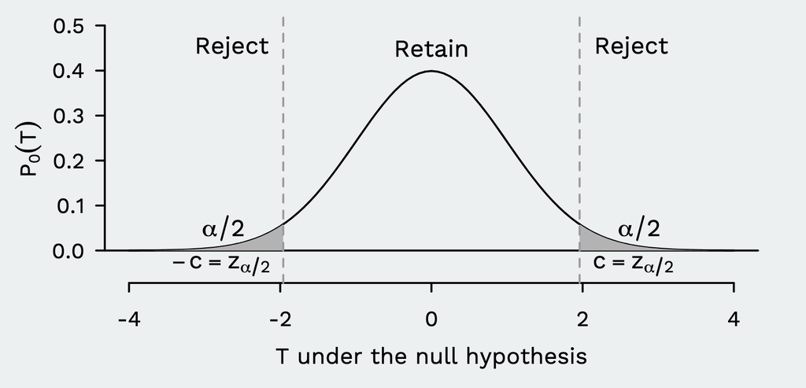

Source: [Blackwell (2016)](https://www.mattblackwell.org/files/teaching/gov2000/s06-hypothesis-tests-slides-print.pdf)

## Average treatment effect (ATE) hypothesis testing

- We have already seen one way to test hypotheses using the potential outcomes framework
  - We estimate the average treatment effect (ATE) and see if the confidence interval includes zero
- This is known as the Jerzy Neyman approach to hypothesis testing
- As potential outcomes are unobservable, we use the observed data to estimate the ATE after randomisation
- Neyman had such a huge impact on experimental methods that many scholars call the potential outcomes framework the Neyman-Rubin model
  - See [here](https://doi.org/10.1093/oxfordhb/9780199286546.003.0011) for more details, and [here](https://projecteuclid.org/journals/statistical-science/volume-5/issue-4/On-the-Application-of-Probability-Theory-to-Agricultural-Experiments-Essay/10.1214/ss/1177012032.full) for a paper by Rubin on the importance of Neyman’s work

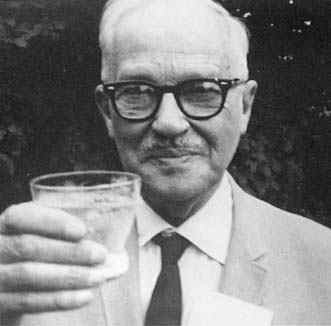

## Sharp null hypothesis 🧐

- But there is another interesting way to test hypotheses!
- The sharp null hypothesis is a hypothesis that is true for all units in the population
  - For instance, “everyone in the population has the same potential outcome under treatment and control”
  - This is a very strong assumption, but it is useful for testing the average treatment effect
  - It is also known as the Ronald Fisher approach to hypothesis testing
- It is based on $p$-values and sampling distributions
- For a comprehensive discussion of the sharp null hypothesis, see [Imbens and Rubin (2015)](https://www.cambridge.org/core/books/abs/causal-inference-for-statistics-social-and-biomedical-sciences/fishers-exact-pvalues-for-completely-randomized-experiments/23AF990D2EF9C90D0A424D555FACE578)
- Let’s see how it works! 😊

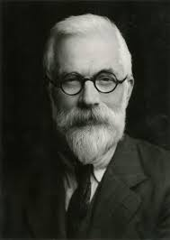

## Hypothesis testing with the sharp null hypothesis

### Randomisation inference

- Sampling variability is a crucial topic in experimental design and analysis
- A single experiment provides just one of many possible datasets generated by random assignment
- The estimate of the average treatment effect can vary substantially depending on the random assignment
- The sampling distribution (or randomisation distribution) refers to the collection of estimates from every possible random assignment
- This hypothesis testing approach is broadly applicable, not limited by sample size or outcome distribution, and can be used with counts, durations, or ranks
- In theory, this calculation can be done for any experiment size, but the number of possible random assignments becomes very large as $N$ increases
- For example, an experiment with $N = 50$ and half assigned to treatment has more than 126 trillion randomisations 😮
  - $\frac{50!}{25! \times 25!} = 126,410,606,437,752$
- But we can approximate the sampling distribution by sampling from all possible random assignments
- Calculating p-values based on an inventory of possible randomisations is called randomisation inference

## Randomisation inference in R

- There is an R package for that! 😊
- The `ri2` package provides tools for randomisation inference, and it was made by the same people who created the `estimatr` package
- You can find more information about the package [here](https://alexandercoppock.com/ri2/)
- Just install it with `install.packages("ri2")` and load it with `library(ri2)`
- The package supports all the randomisation procedures that can be described by the `randomizr` package
- Let’s see how it works!
- Another package that I find useful (and broadly similar to `ri2`) is the `ritest` package, available on GitHub: https://github.com/grantmcdermott/ritest

## Example

### Do female council heads allocate more resources to water sanitation?

- Gerber and Green (2012) describe a hypothetical experiment in which 2 of 7 villages are assigned a female council head and the outcome is the share of the local budget allocated to water sanitation
- Their table 2.2 describes one way the experiment could have come out

```r
library(ri2)
library(estimatr)

# Create the data
table_2_2 <- data.frame(T = c(1, 0, 0, 0, 0, 0, 1),
                        Y = c(15, 15, 20, 20, 10, 15, 30))

summary(lm_robust(Y ~ T, data = table_2_2))
```

```
Call:
lm_robust(formula = Y ~ T, data = table_2_2)

Standard error type:  HC2

Coefficients:
            Estimate Std. Error t value Pr(>|t|) CI Lower CI Upper DF
(Intercept)     16.0      1.871  8.5524  0.00036    11.19    20.81  5
T                6.5      7.730  0.8409  0.43876   -13.37    26.37  5

Multiple R-squared:  0.2485 ,   Adjusted R-squared:  0.09824
F-statistic: 0.7071 on 1 and 5 DF,  p-value: 0.4388
```

## Randomisation inference

```r
# Declare randomisation procedure
declaration <- declare_ra(N = 7, m = 2)

# Conduct Randomisation Inference
ri2_out <- conduct_ri(
  formula = Y ~ T,
  assignment = "T",
  declaration = declaration,
  sharp_hypothesis = 0,
  data = table_2_2,
  sims = 1000
)

summary(ri2_out)
```

```
  term estimate two_tailed_p_value
1    T      6.5          0.3809524
```

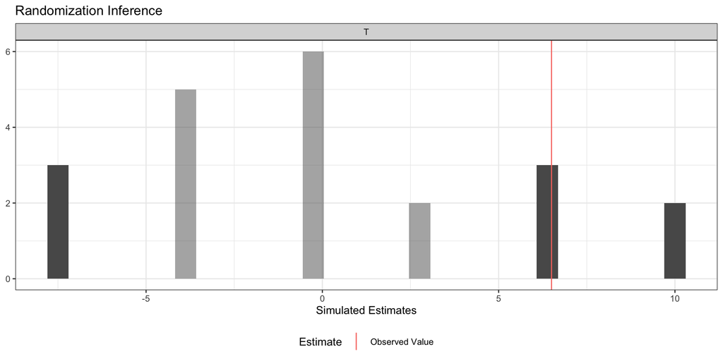

```r
plot(ri2_out)
```

## Another example!

### Effect of not having a runoff in sub-Saharan Africa

- The data to the right, from [Glynn and Ichino (2015)](https://onlinelibrary.wiley.com/doi/abs/10.1111/ajps.12154), examine the relationship between the absence of a runoff election ($A_i = 1$) and harassment of opposition parties ($Y_i$)
- Data were collected from 10 sub-Saharan African countries
- The study suggests that without runoff elections, incumbents can win with a simple plurality, reducing their need to court smaller parties
- This creates incentives to suppress turnout through intimidation
- Conversely, with a runoff ($A_i = 0$), incumbents need broader support and are more likely to engage smaller parties rather than intimidate them

| Unit | $Y_i(0)$ | $Y_i(1)$ | $A_i$ | $Y_i$ |
| --- | --- | --- | --- | --- |
| Cameroon | ? | 1 | 1 | 1 |
| Kenya | ? | 1 | 1 | 1 |
| Malawi | ? | 1 | 1 | 1 |
| Nigeria | ? | 1 | 1 | 1 |
| Tanzania | ? | 0 | 1 | 0 |
| Congo | 0 | ? | 0 | 0 |
| Madagascar | 0 | ? | 0 | 0 |
| Central African Republic | 0 | ? | 0 | 0 |
| Ghana | 0 | ? | 0 | 0 |
| Guinea-Bissau | 0 | ? | 0 | 0 |

Source: [Blackwell (2013)](https://www.mattblackwell.org/files/teaching/s05-fisher.pdf)

## Sharp null hypothesis

| Unit | $Y_i(0)$ | $Y_i(1)$ | $A_i$ | $Y_i$ |
| --- | --- | --- | --- | --- |
| Cameroon | 1 | 1 | 1 | 1 |
| Kenya | 1 | 1 | 1 | 1 |
| Malawi | 1 | 1 | 1 | 1 |
| Nigeria | 1 | 1 | 1 | 1 |
| Tanzania | 0 | 0 | 1 | 0 |
| Congo | 0 | 0 | 0 | 0 |
| Madagascar | 0 | 0 | 0 | 0 |
| Central African Republic | 0 | 0 | 0 | 0 |
| Ghana | 0 | 0 | 0 | 0 |
| Guinea-Bissau | 0 | 0 | 0 | 0 |

```r
gi_data <- data.frame(Y = c(1, 1, 1, 1, 0, 0, 0, 0, 0, 0),
                      A = c(1, 1, 1, 1, 1, 0, 0, 0, 0, 0))

declaration <- declare_ra(N = 10, m = 5)

ri2_out <- conduct_ri(
  formula = Y ~ A,
  assignment = "A",
  declaration = declaration,
  sharp_hypothesis = 0,
  data = gi_data,
  sims = 1000
)

summary(ri2_out)
```

```
  term estimate two_tailed_p_value
1    A      0.8         0.04761905
```

# So far, so good? 😃

# Let’s discuss a real experiment! 🤓

## Bottom-up accountability and public service provision: Evidence from a field experiment in Brazil

### By yours truly! 😊 https://doi.org/10.1177/2053168020914444

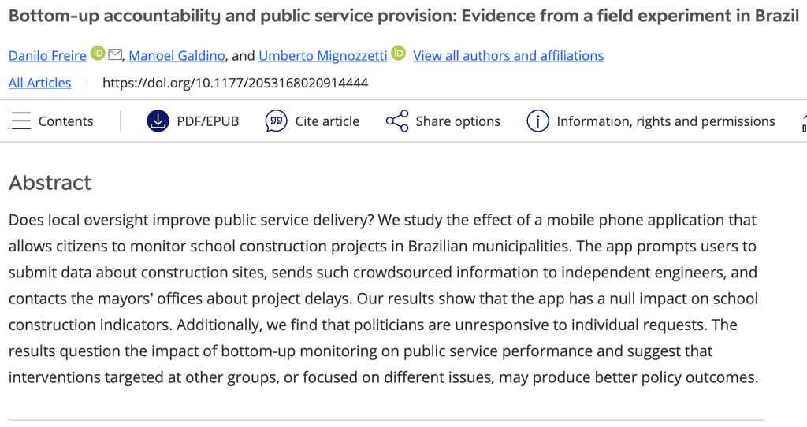

## Outline of the paper: Introduction

### Based on the [EGAP Research Design Form](https://danilofreire.github.io/datasci385/design-form.html)

- Researcher name: Danilo Freire, Manoel Galdino, and Umberto Mignozzetti
- Research project title: Bottom-up accountability and public service provision: Evidence from a field experiment in Brazil
- One sentence summary of your specific research question: Does a mobile phone application that enables citizen monitoring of school construction projects improve public service delivery?
- General motivation: Accountability systems are crucial for efficient public service provision, and there is a belief that bottom-up monitoring can help with the principal-agent dilemma
- Why should someone who is not an academic care about the results of this research?: How technology can help citizens ensure government accountability in young democracies
- Theoretical motivation: Debate between studies showing the positive impacts of information-based interventions and those that find little evidence
- Primary hypotheses:
  - Key parameter/estimands: The key parameters/estimands are the impacts of the TDP app on: (1) percentage of project completed; (2) difference in completion before and after intervention; (3) if the construction is finished; (4) if the construction is canceled; and (5) number of updated dates.
  - Predicted sign/magnitude: The primary hypothesis is that the TDP app will have a positive effect on (1), (2), (3), and (5) leading to higher completion rates. Conversely, the app will have a negative effect on (4) leading to less cancelations.
  - Logic or theory of change: Providing citizens with information about school construction projects empowers them to pressure officials, leading to faster and better completion.

## Outline of the paper: Introduction

### Based on the [EGAP Research Design Form](https://danilofreire.github.io/datasci385/design-form.html)

- Alternative explanations if results are consistent with hypotheses:
  - Alternative theories: Increased community engagement and public awareness, that generates other forms of engagement and pressuring. Increased media coverage of school construction could coincide with the programme
- Hypothesis for alternative outcome: With an increase in media attention regarding public works, we would expect an overall improvement in public services, not a change that is specific to the treatment group.
- Alternative explanations if results are inconsistent with hypotheses:
  - Alternative theories: Difficulties in differentiating political corruption from budget issues; the lack of political pressure; the lack of trust in representatives
  - Hypothesis for alternative outcome: Citizens may not trust their representatives and think the problems are related to austerity instead of corruption

## Section 3: Intervention

- Status Quo:
  - School construction projects in Brazil often face delays.
  - No prior system for citizens to directly report problems and pressure authorities in this way.
- Intervention:
  - Mobile app (Tá de Pé - TDP) enabling citizens to monitor school construction sites.
  - Features: submit photos, check status, send requests to mayor’s offices.
- Control:
  - Intervention 1: No access to TDP app in control municipalities
  - Intervention 2: No access to TDP app at control schools
  - Pure control (no intervention); controls for external factors and placebo effects associated with knowing about the existence of the app
- Units:
  - Intervention 1: Municipality level.
  - Intervention 2: School level.
  - Outcomes measured at the same level (municipality and school, respectively).
- Compliance:
  - “Taking” the intervention means the municipality/school had access to the app.
  - Compliance is whether the app was accessible, not level of engagement.
- Non-Compliance:
  - Potential for users in control group to download the app, but data analysis accounts for this.
  - No concern about those in treatment group not using the app as participation is voluntary.
- Ethics:
  - Control is status quo, so no worse than current conditions.
  - No coercion as app is voluntary.

## Section 3: Intervention

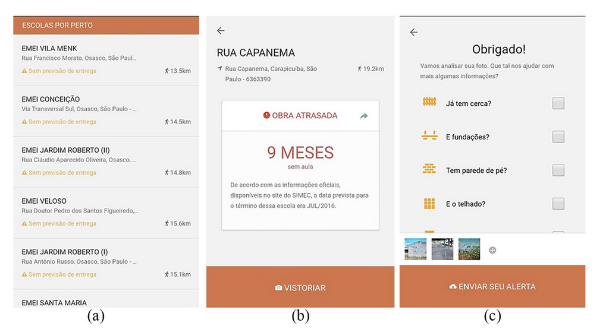

## Section 3: Intervention

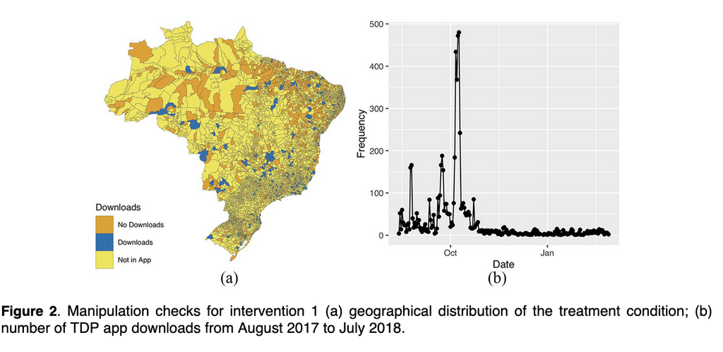

## Section 4: Outcomes and Covariates

- Primary Outcome: Completion status of school construction projects
- Measurement:
  - Percentage of project completed (continuous)
  - Difference in completion before/after intervention (continuous)
  - Finished construction (binary)
  - Cancelled construction (binary)
  - Number of updated completion dates by firms (count)
  - Data come from the Ministry of Education’s SIMEC platform and were accessed via its API
- Priors: Prior studies showed variation in project completion rates, with delays common
- Validity and measurement error:
- Data is based on official government records, reducing untruthful reporting concerns
- Potential for time lags in updating information, but not a major concern for the study design
- Covariates:
- Municipal population, poverty, federal transfers, primary and secondary school quality
- Data is from the Brazilian Ministry of Education and the Brazilian Census
- No additional outcomes or covariates collected to distinguish between explanations and alternatives; however, the randomisation at the municipality/school level is designed to account for these biases
- Ethics:
- Data collection from SIMEC data is minimal in burden and has clear benefits for public policy and accountability

## Section 5: Randomisation

- Randomisation strategy:
- Intervention 1: Cluster randomisation at the municipal level
- Intervention 2: Blocked randomisation at the school level
- Blocks:
- Intervention 1: No blocks
- Intervention 2: Blocks created based on the strata (Brazilian states, construction status, and municipal spending median)
- Clusters:
- Intervention 1: Clusters are municipalities. 344 control clusters and 2642 treatment clusters
- Intervention 2: Not clustered
- Randomising at the individual level was not feasible

## Section 6: Analysis

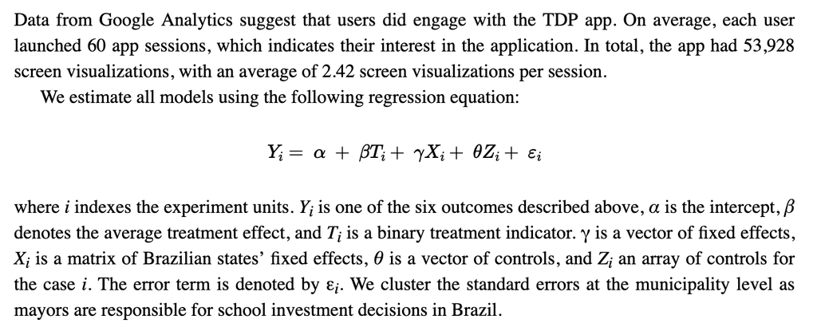

## Section 7: Implementation

- Randomisation:
- Randomisation was conducted on a computer
- Implementation:
- Transparência Brasil implemented the intervention by creating the app and by making it available in a subset of municipalities/schools
- No direct dangers to the research team or enumerators, as all data was collected through APIs and public databases
- Implementation was tracked via app downloads and user sessions
- Compliance:
  - Compliance measured by analysing whether the app was available for use in a given location
  - All compliance data came from the app store and from usage logs
- Data management:
- Data were stored securely on cloud servers
- Data were anonymised by using city/school identification and not user information
- Publicly available data were collected directly via APIs or downloaded directly from the ministry’s site

## Results

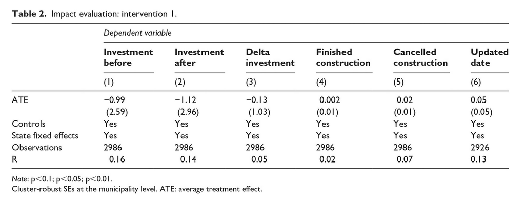

## Results

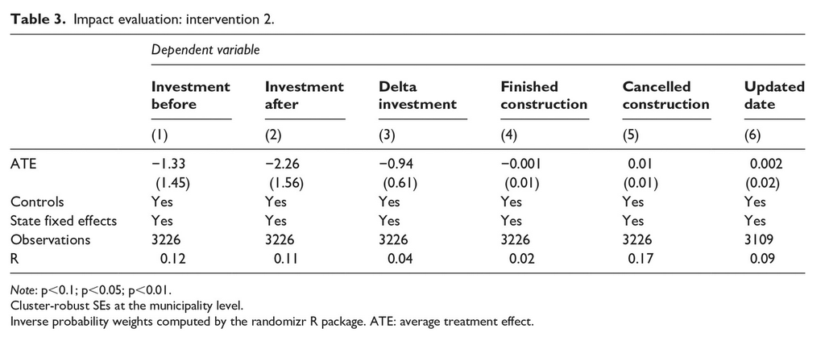

## Randomisation inference! 🤓

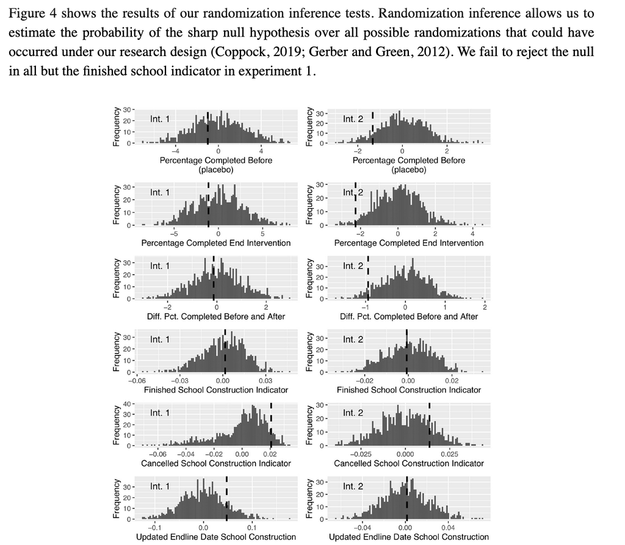

# …and that’s it! 😊

# Thank you, and see you soon! 🙏🏼